# PHD ON BIG DATA

###### insofe pune B55 batch , ID NO -2579B55

# Problem Statement: Build a customer churn prediction model using Spark MLlib (Spark’s machine learning library).

## IMPORT LIBRARIES

```python
# Set Python - Spark environment.
import os
import sys
from os import environ
environ['PYSPARK_SUBMIT_ARGS'] = '--packages com.databricks:spark-xml_2.11:0.5.0 pyspark-shell'
os.environ["SPARK_HOME"] = "/usr/hdp/current/spark2-client"
os.environ["PYLIB"] = os.environ["SPARK_HOME"] + "/python/lib"
sys.path.insert(0, os.environ["PYLIB"] + "/py4j-0.10.6-src.zip")
sys.path.insert(0, os.environ["PYLIB"] + "/pyspark.zip")
```

```python
from pyspark.sql.types import*
from pyspark.sql.functions import*
```

```python
## Create SparkContext, SparkSession
from os.path import expanduser, join, abspath

from pyspark.sql import SparkSession
from pyspark.sql import Row

# warehouse_location points to the default location for managed databases and tables
warehouse_location = 'hdfs:///apps/hive/warehouse/'

spark = SparkSession \
    .builder \
    .appName("Machine Learning Example using Spark ML") \
    .config("spark.sql.warehouse.dir", warehouse_location) \
    .enableHiveSupport() \
    .getOrCreate()

sc = spark.sparkContext
```

```python
spark
```

**SparkSession - hive**

**SparkContext**

[Spark UI](http://u.insofe.edu.in:4041)

**Version**

`v2.3.0.2.6.5.0-292`

**Master**

`local[*]`

**AppName**

`Machine Learning Example using Spark ML`

# Part A: Data Preparation

#### FLUME PROPERTIES FILE

- agent.sources = phdSource1
- agent.channels = memoryChannel
- agent.sinks = phdSink
- agent.sources.phdSource1.type = exec
- agent.sources.phdSource1.command = sh /home/2579B55/xmltocsvphd1.sh
- agent.channels.memoryChannel.type = memory
- agent.channels.memoryChannel.capacity = 10000
- agent.channels.memoryChannel.transactionCapacity = 1000
- agent.sinks.phdSink.type = org.apache.flume.sink.kafka.KafkaSink
- agent.sinks.phdSink.topic = 2579B55_phd_Sink1
- agent.sinks.phdSink.brokerList = c.insofe.edu.in:9092
- agent.sinks.phdSink.batchSize = 100
- agent.sources.phdSource1.channels = memoryChannel
- agent.sinks.phdSink.channel = memoryChannel

## create topic

```python
#kafka-topics.sh --create --zookeeper c.insofe.edu.in:2181 --replication-factor 1 --partitions 1 --topic 2579B55_phd_Sink1
```

# Part B: Pre processing and Model Building

### import file from hdfs

```python
##hdfs dfs -put /home/2579B55/PHD/customer_profile_data-1556930512566.xml  /user/2579B55/
##hdfs dfs -put /home/2579B55/PHD/customer_billing_data-1556930487000.json  /user/2579B55/
```

### Task1: Create the DataFrames for the two files ‘customer_profile_data’ and ‘customer_billing_data’.

###### Reading & Understanding the Data

```python
customer_billing_data = spark.read.format("json")\
.option("inferSchema", "True")\
.load("customer_billing_data-1556930487000.json")
```

```python
customer_billing_data.printSchema()
```

```
root
 |-- MonthlyCharges: double (nullable = true)
 |-- PaymentMethod: string (nullable = true)
 |-- TotalCharges: string (nullable = true)
 |-- customerID: string (nullable = true)
```

```python
customer_profile_data= spark.read.format("xml") \
    .options(rowTag='customer_profile') \
    .option("inferSchema", "true")\
    .load("file:///home/2579B55/PHD/customer_profile_data-1556930512566.xml")
```

```python
customer_profile_data.printSchema()
```

```
root
 |-- Churn: string (nullable = true)
 |-- Contract: string (nullable = true)
 |-- Dependents: string (nullable = true)
 |-- DeviceProtection: string (nullable = true)
 |-- InternetService: string (nullable = true)
 |-- MultipleLines: string (nullable = true)
 |-- OnlineBackup: string (nullable = true)
 |-- OnlineSecurity: string (nullable = true)
 |-- PaperlessBilling: string (nullable = true)
 |-- Partner: string (nullable = true)
 |-- PhoneService: string (nullable = true)
 |-- SeniorCitizen: long (nullable = true)
 |-- StreamingMovies: string (nullable = true)
 |-- StreamingTV: string (nullable = true)
 |-- TechSupport: string (nullable = true)
 |-- customerID: string (nullable = true)
 |-- gender: string (nullable = true)
 |-- tenure: long (nullable = true)
```

### Task2: Verify the row counts of the two DataFrames and check whether the counts are matching or not.

```python
customer_billing_data.count()
```

```
6311
```

```python
customer_profile_data.count()
```

```
6311
```

### Task3: Verify first few rows of both the DataFrames and identify the common column name (key).

```python
customer_billing_data.show(4)
```

```
+--------------+----------------+------------+----------+
|MonthlyCharges|   PaymentMethod|TotalCharges|customerID|
+--------------+----------------+------------+----------+
|          65.6|    Mailed check|       593.3|0002-ORFBO|
|          59.9|    Mailed check|       542.4|0003-MKNFE|
|          73.9|Electronic check|      280.85|0004-TLHLJ|
|          98.0|Electronic check|     1237.85|0011-IGKFF|
+--------------+----------------+------------+----------+
only showing top 4 rows
```

```python
customer_profile_data.show(5)
```

```
+-----+--------------+----------+----------------+---------------+-------------+------------+--------------+----------------+-------+------------+-------------+---------------+-----------+-----------+----------+------+------+
|Churn|      Contract|Dependents|DeviceProtection|InternetService|MultipleLines|OnlineBackup|OnlineSecurity|PaperlessBilling|Partner|PhoneService|SeniorCitizen|StreamingMovies|StreamingTV|TechSupport|customerID|gender|tenure|
+-----+--------------+----------+----------------+---------------+-------------+------------+--------------+----------------+-------+------------+-------------+---------------+-----------+-----------+----------+------+------+
|   No|      One year|       Yes|              No|            DSL|           No|         Yes|            No|             Yes|    Yes|         Yes|            0|             No|        Yes|        Yes|0002-ORFBO|Female|     9|
|   No|Month-to-month|        No|              No|            DSL|          Yes|          No|            No|              No|     No|         Yes|            0|            Yes|         No|         No|0003-MKNFE|  Male|     9|
|  Yes|Month-to-month|        No|             Yes|    Fiber optic|           No|          No|            No|             Yes|     No|         Yes|            0|             No|         No|         No|0004-TLHLJ|  Male|     4|
|  Yes|Month-to-month|        No|             Yes|    Fiber optic|           No|         Yes|            No|             Yes|    Yes|         Yes|            1|            Yes|        Yes|         No|0011-IGKFF|  Male|    13|
|  Yes|Month-to-month|        No|              No|    Fiber optic|           No|          No|            No|             Yes|    Yes|         Yes|            1|             No|        Yes|        Yes|0013-EXCHZ|Female|     3|
+-----+--------------+----------+----------------+---------------+-------------+------------+--------------+----------------+-------+------------+-------------+---------------+-----------+-----------+----------+------+------+
only showing top 5 rows
```

##### observation-

- both dataframes are having same count
- in both of dataframe have customer ID is common column(primary key)

### Task4: Create a DataFrame in cache by combining both the DataFrames using the above common column (key).

```python
customer_billing_data.createOrReplaceTempView("customer_billing_sql_data")
customer_profile_data.createOrReplaceTempView("customer_profile_sql_data")
```

```python
merge_data=spark.sql("""SELECT at.customerID ,at.gender,at.SeniorCitizen,at.Partner,at.Dependents,at.tenure,
at.PhoneService,at.MultipleLines,at.InternetService,at.OnlineSecurity,at.OnlineBackup,at.DeviceProtection,at.TechSupport,
at.StreamingTV,at.StreamingMovies,at.Contract,at.PaperlessBilling,bt.MonthlyCharges,bt.PaymentMethod,bt.TotalCharges,
at.Churn FROM  customer_profile_sql_data at JOIN customer_billing_sql_data bt
  ON at.customerID = bt.customerID""")
```

```python
merge_data.show(2)
```

```
+----------+------+-------------+-------+----------+------+------------+-------------+---------------+--------------+------------+----------------+-----------+-----------+---------------+--------------+----------------+--------------+-------------+------------+-----+
|customerID|gender|SeniorCitizen|Partner|Dependents|tenure|PhoneService|MultipleLines|InternetService|OnlineSecurity|OnlineBackup|DeviceProtection|TechSupport|StreamingTV|StreamingMovies|      Contract|PaperlessBilling|MonthlyCharges|PaymentMethod|TotalCharges|Churn|
+----------+------+-------------+-------+----------+------+------------+-------------+---------------+--------------+------------+----------------+-----------+-----------+---------------+--------------+----------------+--------------+-------------+------------+-----+
|0002-ORFBO|Female|            0|    Yes|       Yes|     9|         Yes|           No|            DSL|            No|         Yes|              No|        Yes|        Yes|             No|      One year|             Yes|          65.6| Mailed check|       593.3|   No|
|0003-MKNFE|  Male|            0|     No|        No|     9|         Yes|          Yes|            DSL|            No|          No|              No|         No|         No|            Yes|Month-to-month|              No|          59.9| Mailed check|       542.4|   No|
+----------+------+-------------+-------+----------+------+------------+-------------+---------------+--------------+------------+----------------+-----------+-----------+---------------+--------------+----------------+--------------+-------------+------------+-----+
only showing top 2 rows
```

#### lets count the data again

```python
merge_data.count()
```

```
6311
```

```python
len(merge_data.columns)
```

```
21
```

*observation:-

##### individual and merged data count are same

### Task6: Verify for the Nulls and NaNs in the data.

```python
merge_dt=merge_data.dropna("any")
print(merge_dt.count())
```

```
6311
```

### Task7: Verify for the blanks/spaces (‘ ’) in the data.

```python
for columns in range(len(merge_dt.columns)):
    print("Spaces count for column {} are {}".format(columns,merge_dt.filter((merge_dt[columns] == " ")).count()))
```

```
Spaces count for column 0 are 0
Spaces count for column 1 are 0
Spaces count for column 2 are 0
Spaces count for column 3 are 0
Spaces count for column 4 are 0
Spaces count for column 5 are 0
Spaces count for column 6 are 0
Spaces count for column 7 are 0
Spaces count for column 8 are 0
Spaces count for column 9 are 0
Spaces count for column 10 are 0
Spaces count for column 11 are 0
Spaces count for column 12 are 0
Spaces count for column 13 are 0
Spaces count for column 14 are 0
Spaces count for column 15 are 0
Spaces count for column 16 are 0
Spaces count for column 17 are 0
Spaces count for column 18 are 0
Spaces count for column 19 are 11
Spaces count for column 20 are 0
```

##### observation- as we can see totalcharges col has 11 null space

### Task8: Remove the rows with spaces, if any and verify there are now rows with the blanks in the DataFrame.

```python
Merge_dtt = merge_dt.filter(merge_dt['TotalCharges']!=" ") # remove spaces
```

```python
Merge_dtt.count()
```

```
6300
```

### Task9. Verify the type of the ‘TotalCharges’ column, change it to Double if not.

```python
merge_data=Merge_dtt
```

```python
merge_data.select('TotalCharges')
```

```
DataFrame[TotalCharges: string]
```

##### as datatypes is string need to converts into Double

```python
merge_data.select(('TotalCharges')).dtypes
```

```
[('TotalCharges', 'string')]
```

```python
from pyspark.sql.functions import expr, col, column
new_merge_data=merge_data.withColumn("TotalCharges", col("TotalCharges").cast("Double"))
```

```python
new_merge_data.printSchema()
```

```
root
 |-- customerID: string (nullable = true)
 |-- gender: string (nullable = true)
 |-- SeniorCitizen: long (nullable = true)
 |-- Partner: string (nullable = true)
 |-- Dependents: string (nullable = true)
 |-- tenure: long (nullable = true)
 |-- PhoneService: string (nullable = true)
 |-- MultipleLines: string (nullable = true)
 |-- InternetService: string (nullable = true)
 |-- OnlineSecurity: string (nullable = true)
 |-- OnlineBackup: string (nullable = true)
 |-- DeviceProtection: string (nullable = true)
 |-- TechSupport: string (nullable = true)
 |-- StreamingTV: string (nullable = true)
 |-- StreamingMovies: string (nullable = true)
 |-- Contract: string (nullable = true)
 |-- PaperlessBilling: string (nullable = true)
 |-- MonthlyCharges: double (nullable = true)
 |-- PaymentMethod: string (nullable = true)
 |-- TotalCharges: double (nullable = true)
 |-- Churn: string (nullable = true)
```

### Task10: Replace the values in ‘SeniorCitizen’ column as

### 0 – No

### 1 – Yes

```python
from pyspark.sql.functions import when
new_merge_data.withColumn("SeniorCitizen",when(new_merge_data["SeniorCitizen"] == "Yes", 1).otherwise(0))
```

```
DataFrame[customerID: string, gender: string, SeniorCitizen: int, Partner: string, Dependents: string, tenure: bigint, PhoneService: string, MultipleLines: string, InternetService: string, OnlineSecurity: string, OnlineBackup: string, DeviceProtection: string, TechSupport: string, StreamingTV: strin…
```

```python
#new_merge_data=new_data.withColumn("SeniorCitizen", col("SeniorCitizen").cast("string"))
```

```python
new_data=new_merge_data
```

```python
new_data.show(5)
```

```
+----------+------+-------------+-------+----------+------+------------+-------------+---------------+--------------+------------+----------------+-----------+-----------+---------------+--------------+----------------+--------------+----------------+------------+-----+
|customerID|gender|SeniorCitizen|Partner|Dependents|tenure|PhoneService|MultipleLines|InternetService|OnlineSecurity|OnlineBackup|DeviceProtection|TechSupport|StreamingTV|StreamingMovies|      Contract|PaperlessBilling|MonthlyCharges|   PaymentMethod|TotalCharges|Churn|
+----------+------+-------------+-------+----------+------+------------+-------------+---------------+--------------+------------+----------------+-----------+-----------+---------------+--------------+----------------+--------------+----------------+------------+-----+
|0002-ORFBO|Female|            0|    Yes|       Yes|     9|         Yes|           No|            DSL|            No|         Yes|              No|        Yes|        Yes|             No|      One year|             Yes|          65.6|    Mailed check|       593.3|   No|
|0003-MKNFE|  Male|            0|     No|        No|     9|         Yes|          Yes|            DSL|            No|          No|              No|         No|         No|            Yes|Month-to-month|              No|          59.9|    Mailed check|       542.4|   No|
|0004-TLHLJ|  Male|            0|     No|        No|     4|         Yes|           No|    Fiber optic|            No|          No|             Yes|         No|         No|             No|Month-to-month|             Yes|          73.9|Electronic check|      280.85|  Yes|
|0011-IGKFF|  Male|            1|    Yes|        No|    13|         Yes|           No|    Fiber optic|            No|         Yes|             Yes|         No|        Yes|            Yes|Month-to-month|             Yes|          98.0|Electronic check|     1237.85|  Yes|
|0013-EXCHZ|Female|            1|    Yes|        No|     3|         Yes|           No|    Fiber optic|            No|          No|              No|        Yes|        Yes|             No|Month-to-month|             Yes|          83.9|    Mailed check|       267.4|  Yes|
+----------+------+-------------+-------+----------+------+------------+-------------+---------------+--------------+------------+----------------+-----------+-----------+---------------+--------------+----------------+--------------+----------------+------------+-----+
only showing top 5 rows
```

### Task11: Add/Derive a new column ‘bucketized_tenure’ by binning/bucketizing the data in the tenure column using the Bucketizer feature transformer available in pyspark.ml.feature

```python
dt=new_data.withColumn("tenure", col("tenure").cast("Double"))
```

```python
from pyspark.ml.feature import Bucketizer
bucketizer = Bucketizer(splits=[ 0,10,20,30,40,50,60, float('Inf') ],inputCol="tenure", outputCol="bucketized_tenure")
df_buck = bucketizer.setHandleInvalid("keep").transform(dt)

df_buck
```

```
DataFrame[customerID: string, gender: string, SeniorCitizen: bigint, Partner: string, Dependents: string, tenure: double, PhoneService: string, MultipleLines: string, InternetService: string, OnlineSecurity: string, OnlineBackup: string, DeviceProtection: string, TechSupport: string, StreamingTV: st…
```

```python
df_buck.groupBy('bucketized_tenure').count().show()
```

```
+-----------------+-----+
|bucketized_tenure|count|
+-----------------+-----+
|              0.0| 1632|
|              1.0|  841|
|              4.0|  579|
|              3.0|  592|
|              2.0|  690|
|              6.0| 1338|
|              5.0|  628|
+-----------------+-----+
```

### Task12: add/Derive a new column ‘tenure_group’ from the above ‘bucketized_tenure’ column as below, using either broadcast join or udf.

### LET'S DEFINE THE FUNCTION TO CREATE tenure_group col

```python
def tenure(i):
    if i == 0.0:
        return '0.0: 0.0 as tenure_0-10'
    elif i == 1.0:
        return '1.0: 0.0 as tenure_10-20'
    elif i == 2.0:
        return '2.0: 0.0 as tenure_20-30'
    elif i == 3.0:
        return '3.0: 0.0 as tenure_30-40'
    elif i == 4.0:
        return '4.0: 0.0 as tenure_40-50'
    elif i == 5.0:
        return '5.0: 0.0 as tenure_50-60'
    elif i == 6.0:
        return '6.0: 0.0 as tenure_60-and-above'
```

```python
from pyspark.sql.functions import udf

maturity_udf = udf(tenure)
df_new=df_buck.withColumn("tenure_group", maturity_udf(df_buck.bucketized_tenure))
```

```python
df_new.groupby('tenure_group').count().show()
```

```
+--------------------+-----+
|        tenure_group|count|
+--------------------+-----+
|0.0: 0.0 as tenur...| 1632|
|1.0: 0.0 as tenur...|  841|
|5.0: 0.0 as tenur...|  628|
|3.0: 0.0 as tenur...|  592|
|2.0: 0.0 as tenur...|  690|
|6.0: 0.0 as tenur...| 1338|
|4.0: 0.0 as tenur...|  579|
+--------------------+-----+
```

### Task13: Remove the ‘bucketized_tenure’ column from the DataFrame.

```python
df_buck3=df_new.drop("bucketized_tenure")
```

### Task14: Identify the categorical and numerical columns.

```python
cat_Var_Names = ['gender', 'SeniorCitizen', 'Partner', 'Dependents', 'PhoneService',
                  'MultipleLines', 'InternetService', 'OnlineSecurity',"OnlineBackup","DeviceProtection",
                 "TechSupport","StreamingTV","StreamingMovies","Contract","PaperlessBilling","PaymentMethod"]

num_Var_Names = ['tenure', 'MonthlyCharges', 'TotalCharges']
```

### Task15: Find customer attrition in the data – Counts of 2 groups in ‘Churn’.

```python
df_buck3.groupBy('Churn').count().show()
```

```
+-----+-----+
|Churn|count|
+-----+-----+
|   No| 4641|
|  Yes| 1659|
+-----+-----+
```

### Task16: Find pair-wise frequencies of the ‘Churn’ and each of the categorical columns and list your observations, if any.

```python
for i in cat_Var_Names:
    df_buck3.crosstab('Churn',i).show()
```

```
+------------+------+----+
|Churn_gender|Female|Male|
+------------+------+----+
|          No|  2289|2352|
|         Yes|   838| 821|
+------------+------+----+

+-------------------+----+---+
|Churn_SeniorCitizen|   0|  1|
+-------------------+----+---+
|                 No|4047|594|
|                Yes|1236|423|
+-------------------+----+---+

+-------------+----+----+
|Churn_Partner|  No| Yes|
+-------------+----+----+
|           No|2189|2452|
|          Yes|1069| 590|
+-------------+----+----+

+----------------+----+----+
|Churn_Dependents|  No| Yes|
+----------------+----+----+
|              No|3040|1601|
|             Yes|1376| 283|
+----------------+----+----+

+------------------+---+----+
|Churn_PhoneService| No| Yes|
+------------------+---+----+
|                No|470|4171|
|               Yes|149|1510|
+------------------+---+----+

+-------------------+----+----------------+----+
|Churn_MultipleLines|  No|No phone service| Yes|
+-------------------+----+----------------+----+
|                 No|2257|             470|1914|
|                Yes| 746|             149| 764|
```

[output cut: 56 more lines]

```
+--------------+--------------+--------+--------+

+----------------------+----+----+
|Churn_PaperlessBilling|  No| Yes|
+----------------------+----+----+
|                    No|2126|2515|
|                   Yes| 415|1244|
+----------------------+----+----+

+-------------------+-------------------------+-----------------------+----------------+------------+
|Churn_PaymentMethod|Bank transfer (automatic)|Credit card (automatic)|Electronic check|Mailed check|
+-------------------+-------------------------+-----------------------+----------------+------------+
|                 No|                     1175|                   1150|            1152|        1164|
|                Yes|                      230|                    204|             960|         265|
+-------------------+-------------------------+-----------------------+----------------+------------+
```

##### observation-observation:-

##### 1.year of contract of plays vital role in Tenure of customers

##### 2.month -month contract customers are more likely left the service.

##### 3.as two contract customers are less likely to switch there service.

##### 4.most of people with less than 1 year taking service switch the service early.

### Task17: Find average ‘MonthlyCharges’ and average ‘TotalCharges’ for each tenure_group and Churn combination, and list your observations,

```python
from pyspark.sql.functions import sum, count, avg, expr

df_buck3.groupby('tenure_group',"Churn").agg({'MonthlyCharges': 'mean'}).show()
```

```
+--------------------+-----+-------------------+
|        tenure_group|Churn|avg(MonthlyCharges)|
+--------------------+-----+-------------------+
|0.0: 0.0 as tenur...|   No| 46.433677184466035|
|1.0: 0.0 as tenur...|  Yes|  76.69963636363636|
|3.0: 0.0 as tenur...|   No|  62.76709677419356|
|4.0: 0.0 as tenur...|  Yes|  87.31201923076924|
|5.0: 0.0 as tenur...|   No|  67.04849624060145|
|6.0: 0.0 as tenur...|  Yes|  97.04261363636361|
|2.0: 0.0 as tenur...|  Yes|  82.47732919254656|
|2.0: 0.0 as tenur...|   No|  56.13733459357274|
|4.0: 0.0 as tenur...|   No|  62.89431578947371|
|6.0: 0.0 as tenur...|   No|  74.50835999999998|
|1.0: 0.0 as tenur...|   No|  51.81775618374556|
|5.0: 0.0 as tenur...|  Yes|  88.19479166666667|
|3.0: 0.0 as tenur...|  Yes|  83.47598425196848|
|0.0: 0.0 as tenur...|  Yes|  64.99610148514849|
+--------------------+-----+-------------------+
```

##### observation:-the customers pays monthly charges more than mean values are likrly to change the services where as huge number of peoples who are less paid are not changing the service

```python
df_buck3.groupby('tenure_group',"Churn").agg({'TotalCharges': 'mean'}).show()
```

```
+--------------------+-----+------------------+
|        tenure_group|Churn| avg(TotalCharges)|
+--------------------+-----+------------------+
|0.0: 0.0 as tenur...|   No|  205.059890776699|
|1.0: 0.0 as tenur...|  Yes|1065.1640000000007|
|3.0: 0.0 as tenur...|   No|2143.0656989247323|
|4.0: 0.0 as tenur...|  Yes|3886.7850961538456|
|5.0: 0.0 as tenur...|   No|3658.0194548872196|
|6.0: 0.0 as tenur...|  Yes| 6474.805681818182|
|2.0: 0.0 as tenur...|  Yes|1997.4164596273283|
|2.0: 0.0 as tenur...|   No|1375.9159735349701|
|4.0: 0.0 as tenur...|   No| 2806.652105263158|
|6.0: 0.0 as tenur...|   No| 5059.005000000003|
|1.0: 0.0 as tenur...|   No| 748.7657243816249|
|5.0: 0.0 as tenur...|  Yes|4793.2380208333325|
|3.0: 0.0 as tenur...|  Yes| 2858.481496062992|
|0.0: 0.0 as tenur...|  Yes|219.51949257425753|
+--------------------+-----+------------------+
```

##### observation:total charges and monthly charges mightbe having a high correlated

### Task18: Remove ‘tenure_group’ column from the DataFrame and from the corresponding columns list if you create any.

```python
final_dt=df_buck3.drop('tenure_group')
```

### Task19: Add/Derive a new column ‘label’ from the ‘Churn’ column by replacing the values in it, ‘No’ as 0.0 and ‘Yes’ as 1.0 . Make sure the label column must be double type.

```python
data1=final_dt.withColumn("label1",when(new_merge_data["Churn"] == "Yes", 1).otherwise(0))
```

```python
datadtt=data1.withColumn("label1", col("label1").cast("string"))
```

```python
data1=datadtt
```

```python
data1.groupBy('label1').count().show()
```

```
+------+-----+
|label1|count|
+------+-----+
|     0| 4641|
|     1| 1659|
+------+-----+
```

### Task20: Drop the ‘Churn’ column from the DataFrame.

```python
final_dt2=data1.drop('Churn')
```

```python
final_data=final_dt2.drop_duplicates()
```

# Build the model

### Task21: Define the SparkMl Pipelines for the preprocessing stages as below.

```python
cat_Var_Names = ['gender', 'SeniorCitizen', 'Partner', 'Dependents', 'PhoneService',
                  'MultipleLines', 'InternetService', 'OnlineSecurity',"OnlineBackup","DeviceProtection",
                 "TechSupport","StreamingTV","StreamingMovies","Contract","PaperlessBilling","PaymentMethod"]

num_Var_Names = ['tenure', 'MonthlyCharges', 'TotalCharges']
```

```python
from pyspark.ml.feature import OneHotEncoder, StringIndexer
from pyspark.ml.feature import StandardScaler
from pyspark.ml.feature import VectorAssembler

vector_assembler_NumVars = VectorAssembler(inputCols=num_Var_Names,
                                           outputCol="num_features_all")

standardScaler_NumVars = StandardScaler(inputCol="num_features_all",
                                      outputCol = "scaled_num_features")

indexers_Cat  = [StringIndexer(inputCol=cat_Var_Name,
                               outputCol="{0}_index".format(cat_Var_Name))
                 for cat_Var_Name in cat_Var_Names ]

encoders_Cat  = [OneHotEncoder(inputCol=indexer.getOutputCol(),
                               outputCol="{0}_vec".format
                               (indexer.getInputCol()))
                 for indexer in indexers_Cat]

assembler_Cat = VectorAssembler(inputCols=[encoder.getOutputCol()
                                           for encoder in encoders_Cat],
                                outputCol="cat_features")

assembler     = VectorAssembler(inputCols=["scaled_num_features","cat_features"],
                                outputCol="features")
```

```python
type(vector_assembler_NumVars)
```

```
pyspark.ml.feature.VectorAssembler
```

```python
indexer_Label = StringIndexer(inputCol="label1", outputCol="label")
```

```python
preprocessiong_Stages = [vector_assembler_NumVars] +\
                        [standardScaler_NumVars] +\
                        indexers_Cat + encoders_Cat +\
                        [assembler_Cat] +\
                        [assembler] +\
                        [indexer_Label]
```

### Task22: Split the data as train and validation sets.

```python
final1=final_data.dropna()
```

```python
(trainingData, testData) = final1.randomSplit([0.7, 0.3])
```

```python
trainingData.dtypes
```

```
[('customerID', 'string'),
 ('gender', 'string'),
 ('SeniorCitizen', 'bigint'),
 ('Partner', 'string'),
 ('Dependents', 'string'),
 ('tenure', 'double'),
 ('PhoneService', 'string'),
 ('MultipleLines', 'string'),
 ('InternetService', 'string'),
 ('OnlineSecurity', 'string'),
 ('OnlineBackup', 'string'),
 ('DeviceProtection', 'string'),
 ('TechSupport', 'string'),
 ('StreamingTV', 'string'),
 ('StreamingMovies', 'string'),
 ('Contract', 'string'),
 ('PaperlessBilling', 'string'),
 ('MonthlyCharges', 'double'),
 ('PaymentMethod', 'string'),
 ('TotalCharges', 'double'),
 ('label1', 'string')]
```

### Task23: Build a machine learning classifier

```python
from pyspark.ml import Pipeline
new_data_mod = Pipeline(stages=preprocessiong_Stages)
new_data_trnfm = new_data_mod.fit(trainingData)
new_data = new_data_trnfm.transform(trainingData)
```

```python
from pyspark.mllib.tree import RandomForest, RandomForestModel
from pyspark.mllib.util import MLUtils
from pyspark.ml.classification import RandomForestClassifier
lr =  RandomForestClassifier(labelCol="label", featuresCol="features")
```

```python
from pyspark.ml import Pipeline
from pyspark.ml.tuning import ParamGridBuilder, CrossValidator
from pyspark.ml.evaluation import MulticlassClassificationEvaluator

lr_Pipeline = Pipeline(stages=preprocessiong_Stages+[lr])

evaluator = MulticlassClassificationEvaluator(metricName="accuracy")
paramGrid = ParamGridBuilder()\
    .addGrid(lr.numTrees, [20,50])\
    .addGrid(lr.maxDepth, [5,7])\
    .build()


lr_crossval = CrossValidator(estimator=lr_Pipeline,
                             estimatorParamMaps=paramGrid,
                             evaluator=evaluator,
                             numFolds=2)

lr_Pipeline_model= lr_crossval.fit(trainingData)
```

### Task24: Compute the predictions for both ‘train’ and ‘validation’ sets using the pipeline model built in the above step.

```python
train_predictions_lr = lr_Pipeline_model.transform(trainingData)
test_predictions_lr = lr_Pipeline_model.transform(testData)
```

### Task25: Compute accuracy and error for train and validation sets.

```python
from pyspark.ml.evaluation import MulticlassClassificationEvaluator
predictionAndLabels_train_lr = train_predictions_lr.select("prediction",
                                                           "label")
evaluator = MulticlassClassificationEvaluator(metricName="accuracy")
train_accuracy_lr = evaluator.evaluate(predictionAndLabels_train_lr)
print("Train set accuracy  = " + str(train_accuracy_lr))
print("Train Error = %g" % (1.0 - train_accuracy_lr))

predictionAndLabels_test_lr = test_predictions_lr.select("prediction", "label")
test_accuracy_lr = evaluator.evaluate(predictionAndLabels_test_lr)
print("Test set accuracy = " + str(test_accuracy_lr))
print("Test Error = %g" % (1.0 - test_accuracy_lr))
```

```
Train set accuracy  = 0.830852503383
Train Error = 0.169147
Test set accuracy = 0.792068595927
Test Error = 0.207931
```

```python
from pyspark.ml.evaluation import BinaryClassificationEvaluator

# Evaluate model
evaluator = BinaryClassificationEvaluator()
print(evaluator.getMetricName())
print(evaluator.evaluate(train_predictions_lr))
```

```
areaUnderROC
0.892012335566
```

### Task26: Compute Precision, Recall and F1 Score for both train and validation sets.

```python
true_positive = predictionAndLabels_train_lr[(predictionAndLabels_train_lr.label == 1) & (predictionAndLabels_train_lr.prediction == 1.0)].count()
true_negative = predictionAndLabels_train_lr[(predictionAndLabels_train_lr.label == 0) & (predictionAndLabels_train_lr.prediction == 0.0)].count()
false_positive = predictionAndLabels_train_lr[(predictionAndLabels_train_lr.label == 0) & (predictionAndLabels_train_lr.prediction == 1.0)].count()
false_negative = predictionAndLabels_train_lr[(predictionAndLabels_train_lr.label == 1) & (predictionAndLabels_train_lr.prediction == 0.0)].count()
print "TRAIN METRICS "
print "True Positives:", true_positive
print "True Negatives:", true_negative
print "False Positives:", false_positive
print "False Negatives:", false_negative
print "Total", predictionAndLabels_train_lr.count()
precission = true_positive / float(true_positive + false_positive)
print "Precission: ", precission
recall = true_positive / float(true_positive + false_negative)
print "Recall: ", recall
print "F1 Score: ", (2*((precission * recall)/float(precission + recall)))
print("*****************************************************************************")
true_positive = predictionAndLabels_test_lr[(predictionAndLabels_test_lr.label == 1) & (predictionAndLabels_test_lr.prediction == 1.0)].count()
true_negative = predictionAndLabels_test_lr[(predictionAndLabels_test_lr.label == 0) & (predictionAndLabels_test_lr.prediction == 0.0)].count()
false_positive = predictionAndLabels_test_lr[(predictionAndLabels_test_lr.label == 0) & (predictionAndLabels_test_lr.prediction == 1.0)].count()
false_negative = predictionAndLabels_test_lr[(predictionAndLabels_test_lr.label == 1) & (predictionAndLabels_test_lr.prediction == 0.0)].count()
print "TEST METRICS "
print "True Positives:", true_positive
print "True Negatives:", true_negative
print "False Positives:", false_positive
print "False Negatives:", false_negative
print "Total", predictionAndLabels_test_lr.count()
precission = true_positive / float(true_positive + false_positive)
print "Precission: ", precission
recall = true_positive / float(true_positive + false_negative)
print "Recall: ", recall
print "F1 Score: ", (2*((precission * recall)/float(precission + recall)))
```

```
TRAIN METRICS
True Positives: 614
True Negatives: 3070
False Positives: 208
False Negatives: 542
Total 4434
Precission:  0.74695863747
Recall:  0.531141868512
F1 Score:  0.620829120324
TEST METRICS
True Positives: 247
True Negatives: 1231
False Positives: 132
False Negatives: 256
Total 1866
Precission:  0.651715039578
Recall:  0.491053677932
F1 Score:  0.560090702948
```

```python
train_pred_pandas = predictionAndLabels_train_lr.toPandas()
train_actuals = train_pred_pandas.label.tolist()
train_predictions = train_pred_pandas.prediction.tolist()


test_pred_pandas = predictionAndLabels_test_lr.toPandas()
test_actuals = test_pred_pandas.label.tolist()
test_predictions = test_pred_pandas.prediction.tolist()
from sklearn import metrics as smetrics
cm = smetrics.confusion_matrix(train_actuals, train_predictions)
```

```
              Not Approved  Approved
Not Approved          3070       208
Approved               542       614
```

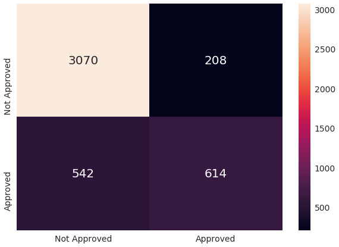

```python
import pandas as pd
import matplotlib.pyplot as plt
import seaborn as sns

df_cm = pd.DataFrame(cm)
df_cm.index = ['Not Approved', 'Approved']
df_cm.columns = ['Not Approved', 'Approved']
names=['Not Approved', 'Approved']
print(df_cm)
fig = plt.figure(figsize = (10,7))
sns.set(font_scale=1.4)#for label size
sns.heatmap(df_cm, annot=True,fmt="d",annot_kws={"size": 20})#
```

### Task27: Create a DataFrame from the hive table ‘test_data_table’ located in ‘insofe_b55_phd_db’ database.

```python
spark.sql('show databases').show(2)
```

```
+--------------------+
|        databaseName|
+--------------------+
|12486_scoop_sql_hive|
|    12523_sqoop_hive|
+--------------------+
only showing top 2 rows
```

```python
spark.sql("use insofe_b55_phd_db")
```

```
DataFrame[]
```

```python
test_df=spark.sql("select * from test_data_table")
```

```python
test_df.printSchema()
```

```
root
 |-- customerid: string (nullable = true)
 |-- gender: string (nullable = true)
 |-- seniorcitizen: string (nullable = true)
 |-- partner: string (nullable = true)
 |-- dependents: string (nullable = true)
 |-- tenure: integer (nullable = true)
 |-- phoneservice: string (nullable = true)
 |-- multiplelines: string (nullable = true)
 |-- internetservice: string (nullable = true)
 |-- onlinesecurity: string (nullable = true)
 |-- onlinebackup: string (nullable = true)
 |-- deviceprotection: string (nullable = true)
 |-- techsupport: string (nullable = true)
 |-- streamingtv: string (nullable = true)
 |-- streamingmovies: string (nullable = true)
 |-- contract: string (nullable = true)
 |-- paperlessbilling: string (nullable = true)
 |-- paymentmethod: string (nullable = true)
 |-- monthlycharges: double (nullable = true)
 |-- totalcharges: double (nullable = true)
```

```python
test_df.count()
```

```
732
```

```python
test_df1=test_df.dropna("any")
print(test_df1.count())
```

```
732
```

### Verify for the blanks/spaces (‘ ’) in the data.

```python
for columns in range(len(test_df1.columns)):
    print("Spaces count for column {} are {}".format(columns,test_df1.filter((test_df1[columns] == " ")).count()))
```

```
Spaces count for column 0 are 0
Spaces count for column 1 are 0
Spaces count for column 2 are 0
Spaces count for column 3 are 0
Spaces count for column 4 are 0
Spaces count for column 5 are 0
Spaces count for column 6 are 0
Spaces count for column 7 are 0
Spaces count for column 8 are 0
Spaces count for column 9 are 0
Spaces count for column 10 are 0
Spaces count for column 11 are 0
Spaces count for column 12 are 0
Spaces count for column 13 are 0
Spaces count for column 14 are 0
Spaces count for column 15 are 0
Spaces count for column 16 are 0
Spaces count for column 17 are 0
Spaces count for column 18 are 0
Spaces count for column 19 are 0
```

### Verify the type of the ‘TotalCharges’ column, change it to Double if not.

```python
test_df1.select('TotalCharges')
```

```
DataFrame[TotalCharges: double]
```

```python
test_df1.columns
```

```
['customerid',
 'gender',
 'seniorcitizen',
 'partner',
 'dependents',
 'tenure',
 'phoneservice',
 'multiplelines',
 'internetservice',
 'onlinesecurity',
 'onlinebackup',
 'deviceprotection',
 'techsupport',
 'streamingtv',
 'streamingmovies',
 'contract',
 'paperlessbilling',
 'paymentmethod',
 'monthlycharges',
 'totalcharges']
```

```python
test_df1.createOrReplaceTempView('test_df_sql')
```

```python
test_data=spark.sql("""SELECT at.customerid customerID ,at.gender  gender,at.seniorcitizen SeniorCitizen,at.partner Partner,at.dependents Dependents,at.tenure tenure,
at.phoneservice PhoneService,at.multiplelines MultipleLines,at.internetservice InternetService,at.onlinesecurity OnlineSecurity,at.onlinebackup OnlineBackup,at.deviceprotection DeviceProtection,
at.techsupport TechSupport,
at.streamingtv StreamingTV,at.streamingmovies StreamingMovies,at.contract Contract,at.paperlessbilling PaperlessBilling,at.monthlycharges MonthlyCharges,at.paymentmethod PaymentMethod,
at.totalcharges TotalCharges FROM  test_df_sql at""")
```

```python
test_data.columns
```

```
['customerID',
 'gender',
 'SeniorCitizen',
 'Partner',
 'Dependents',
 'tenure',
 'PhoneService',
 'MultipleLines',
 'InternetService',
 'OnlineSecurity',
 'OnlineBackup',
 'DeviceProtection',
 'TechSupport',
 'StreamingTV',
 'StreamingMovies',
 'Contract',
 'PaperlessBilling',
 'MonthlyCharges',
 'PaymentMethod',
 'TotalCharges']
```

```python
test_data
```

```
DataFrame[customerID: string, gender: string, SeniorCitizen: string, Partner: string, Dependents: string, tenure: int, PhoneService: string, MultipleLines: string, InternetService: string, OnlineSecurity: string, OnlineBackup: string, DeviceProtection: string, TechSupport: string, StreamingTV: strin…
```

```python
trainingData
```

```
DataFrame[customerID: string, gender: string, SeniorCitizen: bigint, Partner: string, Dependents: string, tenure: double, PhoneService: string, MultipleLines: string, InternetService: string, OnlineSecurity: string, OnlineBackup: string, DeviceProtection: string, TechSupport: string, StreamingTV: st…
```

```python
#test_data3=test_data.withColumn("SeniorCitizen", col("SeniorCitizen").cast("String"))
```

```python
#test_data4=test_data3.withColumn("tenure", col("tenure").cast("int"))
```

```python
from pyspark.sql.functions import lit
test_data3=test_data.select("*", lit(1).alias('label1'))
```

```python
test_data3=test_data3.withColumn("label1", col("label1").cast("string"))
test_data3=test_data3.withColumn("label1", col("label1").cast("string"))
```

```python
new_test_data=test_data3.withColumn("SeniorCitizen",when(test_data3["SeniorCitizen"] == "Yes", 1).otherwise(0))
```

```python
new_test_data
```

```
DataFrame[customerID: string, gender: string, SeniorCitizen: int, Partner: string, Dependents: string, tenure: int, PhoneService: string, MultipleLines: string, InternetService: string, OnlineSecurity: string, OnlineBackup: string, DeviceProtection: string, TechSupport: string, StreamingTV: string, …
```

### Task28: Compute the predictions for the above data using the previously built pipeline model.

```python
test_predictions = lr_Pipeline_model.transform(new_test_data)
```

### Task 29 :Select only the columns ‘customerID’ and ‘prediction’ from the above predictions DataFrame.

```python
test_predictions.select('customerID','prediction').show(10)
```

```
+----------+----------+
|customerID|prediction|
+----------+----------+
|0018-NYROU|       1.0|
|0023-HGHWL|       1.0|
|0027-KWYKW|       1.0|
|0048-PIHNL|       0.0|
|0056-EPFBG|       0.0|
|0068-FIGTF|       0.0|
|0080-EMYVY|       0.0|
|0117-LFRMW|       0.0|
|0122-OAHPZ|       1.0|
|0142-GVYSN|       0.0|
+----------+----------+
only showing top 10 rows
```

```python
test_result=test_predictions.select('customerID','prediction')
```

### Task30: Save the above results as a hive table with the table name as ‘bd*phd*_preds’ in the database ‘insofe_b55_phd_db

```python
test_result.write.mode("overwrite").saveAsTable("bd_phd_2579B55__preds")
```